# MPDW Prak 4

Aquila Putra N.

2026-09-23

```r
library(TSA)
```

# Proses MA(Moving Average) (2)

• Bangkitkan model MA(2) dengan 𝜃1 = 0.4 dan 𝜃2 = 0.6 sebanyak 300 data (Manual dan dengan arima.sim) • Buat plot time series, plot ACF, plot PACF dan plot EACF. Idenifikasi apakah data tersebut stasioner • Buat scatterplot antara 𝑌𝑡 dengan 𝑌𝑡−1, 𝑌𝑡 dengan 𝑌𝑡−2 serta 𝑌𝑡 dengan 𝑌𝑡−3 • Hitung autokorelasi masing masing baik dari data bangkitan maupun secara teoritis

MA (2):
$$Y_t = e_t + \theta_1 e_{t-1} +
\theta_2 e_{t-2}, \qquad e_t \sim WN(0,\sigma_e^2)$$

## Pembangkitan Data

### Dengan arima.sim

```r
set.seed(123)
y_ma2_sim <- arima.sim(model = list(ma = c(0.4, 0.6)), n = 300)
```

```r
y_ma2_sim
```

```
## Time Series:
## Start = 1
## End = 300
## Frequency = 1
##   [1]  1.130351930  0.555885223  1.092716080  1.809085116  1.224514842
##   [6] -0.051655760 -0.916327622 -1.479439852  0.633705298  0.582049364
##  [11]  1.279146060  0.486879592 -0.271105178  1.630986312  0.879111052
##  [16] -0.695329083  0.213419326 -1.372219341 -0.836126728 -0.928779242
##  [21] -1.753888638 -1.270077957 -1.532198429 -2.374043755 -0.211913841
##  [26] -0.523528051 -0.574115463  0.890584017  0.245108028  0.627803158
##  [31]  1.032975601  1.059140862  1.709909873  1.544152779  1.322322404
##  [36]  0.572839503  0.001623244 -0.540003093 -1.030472978 -0.714082670
##  [41] -1.765387450  1.538047058  1.316306573  0.661449795 -0.127351070
##  [46] -1.301674438  0.351572076 -0.051376231  0.687949958  0.022759210
##  [51]  0.097701949  1.334326048  0.295947654  2.247323581 -1.077627154
```

[output cut: 49 more lines]

### Manual

```r
generate_ma2_manual <- function(n, theta1, theta2) {
  burn <- 2
  e <- rnorm(n + burn)
  y <- numeric(n)
  for (t in 1:n) {
    tt <- t + burn
    y[t] <- e[tt] + theta1 * e[tt - 1] + theta2 * e[tt - 2]
  }
  y
}
```

```r
set.seed(123)
y_ma2_manual <- generate_ma2_manual(300, 0.4, 0.6)
y_ma2_manual
```

```
##   [1]  1.130351930  0.555885223  1.092716080  1.809085116  1.224514842
##   [6] -0.051655760 -0.916327622 -1.479439852  0.633705298  0.582049364
##  [11]  1.279146060  0.486879592 -0.271105178  1.630986312  0.879111052
##  [16] -0.695329083  0.213419326 -1.372219341 -0.836126728 -0.928779242
##  [21] -1.753888638 -1.270077957 -1.532198429 -2.374043755 -0.211913841
##  [26] -0.523528051 -0.574115463  0.890584017  0.245108028  0.627803158
##  [31]  1.032975601  1.059140862  1.709909873  1.544152779  1.322322404
##  [36]  0.572839503  0.001623244 -0.540003093 -1.030472978 -0.714082670
##  [41] -1.765387450  1.538047058  1.316306573  0.661449795 -0.127351070
##  [46] -1.301674438  0.351572076 -0.051376231  0.687949958  0.022759210
##  [51]  0.097701949  1.334326048  0.295947654  2.247323581 -1.077627154
##  [56]  0.874994991 -0.571551939  0.616251516  0.540328657 -0.220902719
##  [61] -0.306353075 -1.453252408 -1.679145810 -0.736333079 -0.073453501
##  [66]  0.414405323  1.212395026  2.450794209  0.882363189 -1.275530531
##  [71] -0.212547725 -1.692406678 -0.368245807  0.324847466 -0.287349629
```

[output cut: 45 more lines]

## Plots dan Kestasioneran

**Sifat kestasioneran:** proses MA orde berhingga **selalu stasioner** untuk sembarang nilai $\theta_1, \theta_2$, karena variansi dan kovariansinya tidak bergantung pada $t$ (hanya bergantung pada selisih lag).

### Time Series

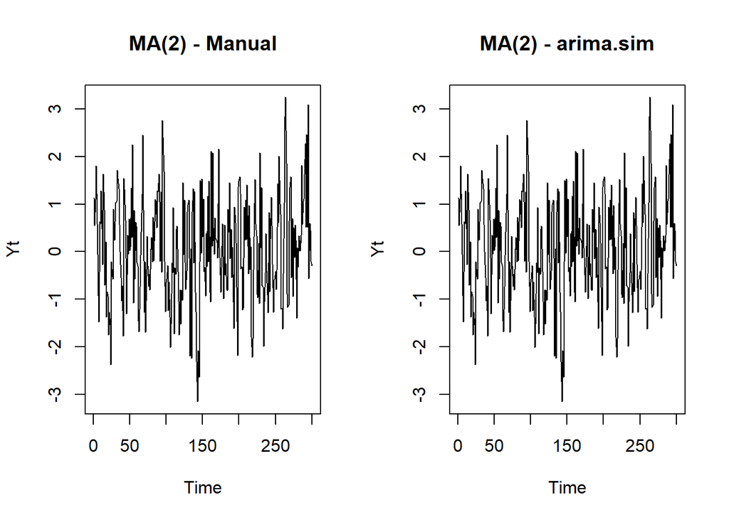

```r
par(mfrow = c(1, 2))
plot.ts(y_ma2_manual, main = "MA(2) - Manual", ylab = "Yt")
plot.ts(y_ma2_sim, main = "MA(2) - arima.sim", ylab = "Yt")
```

```r
par(mfrow = c(1, 1))
```

(Karena sama aja jadinya saya bakal pakai yang y_ma2_sim aja untuk seterusnya)

### ACF

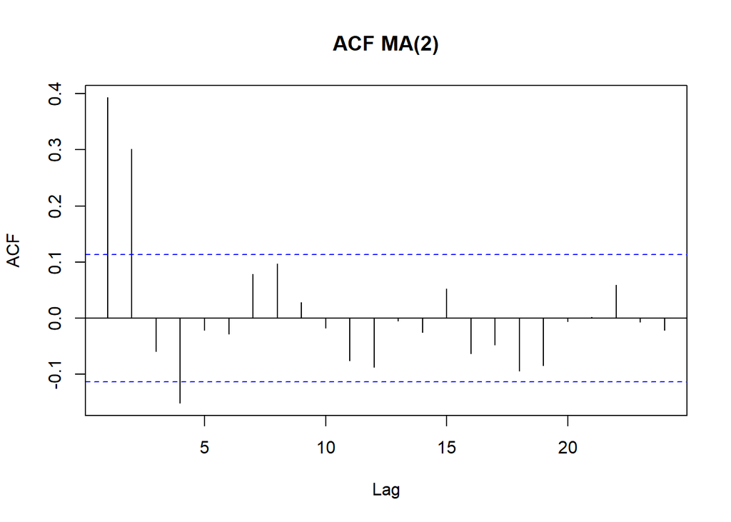

```r
acf(y_ma2_sim, main = "ACF MA(2)")
```

### PACF

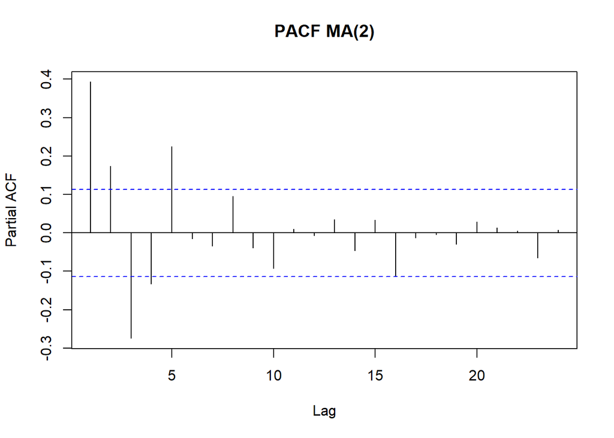

```r
pacf(y_ma2_sim, main = "PACF MA(2)")
```

### EACF

```r
eacf(y_ma2_sim)
```

```
## AR/MA
##   0 1 2 3 4 5 6 7 8 9 10 11 12 13
## 0 x x o x o o o o o o o  o  o  o
## 1 x x x x o o o o o o o  o  o  o
## 2 x x o x o o o o o o o  o  o  o
## 3 x x o o x o o o o o o  o  o  o
## 4 x x x x x o o o o o o  o  o  o
## 5 o x x x x o o o o o o  o  o  o
## 6 x o x x o o o o o o o  o  o  o
## 7 x x o x x o o o o o o  o  o  o
```

## Scatterplot Yt terhadap Lag

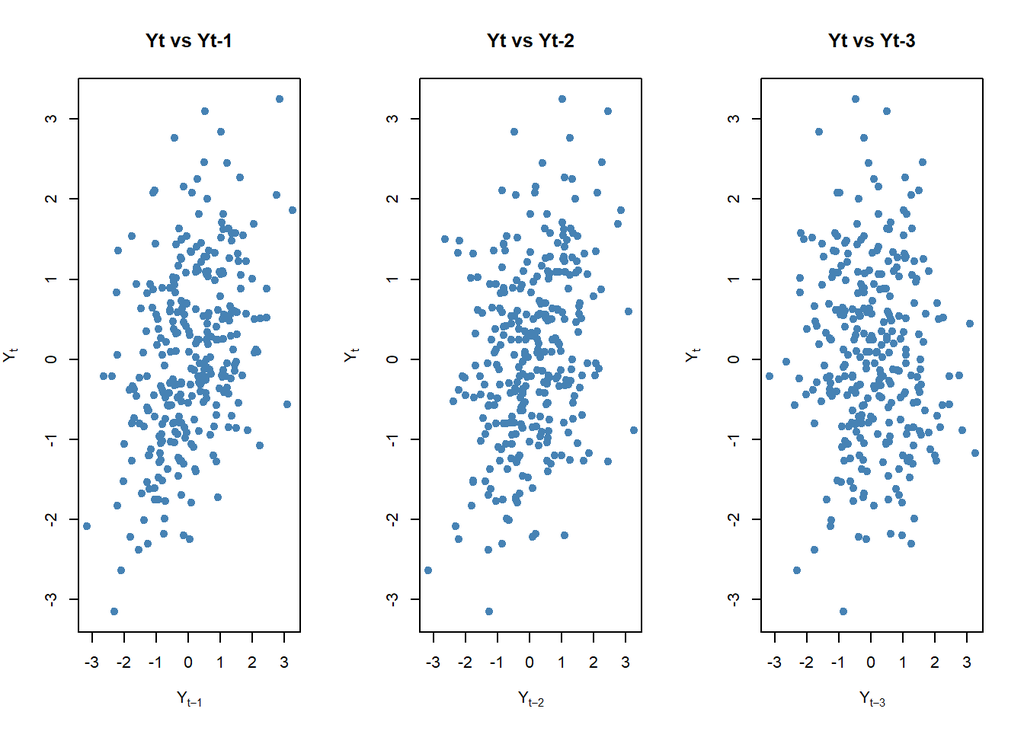

```r
scatter_lag <- function(y, lag, judul) {
  n <- length(y)
  plot(y[1:(n - lag)], y[(1 + lag):n],
       xlab = bquote(Y[t - .(lag)]), ylab = expression(Y[t]),
       main = judul, pch = 19, col = "steelblue")
}

par(mfrow = c(1, 3))
scatter_lag(y_ma2_sim, 1, "Yt vs Yt-1")
scatter_lag(y_ma2_sim, 2, "Yt vs Yt-2")
scatter_lag(y_ma2_sim, 3, "Yt vs Yt-3")
```

```r
par(mfrow = c(1, 1))
```

## Autokorelasi

### Empiris

```r
acf_empiris <- acf(y_ma2_sim, plot = FALSE)$acf[2:4]
acf_empiris
```

```
## [1]  0.3014933 -0.0587174 -0.1512968
```

### Teoritis

$$\rho_k =
\begin{cases}
1, & k = 0\\[4pt]
\dfrac{\theta_1+\theta_1\theta_2}{1+\theta_1^2+\theta_2^2}, & k =
1\\[8pt]
\dfrac{\theta_2}{1+\theta_1^2+\theta_2^2}, & k = 2\\[4pt]
0, & k > 2
\end{cases}$$

```r
theta1 <- 0.4
theta2 <- 0.6

denom <- 1 + theta1^2 + theta2^2
rho1_teori <- (theta1 + theta1 * theta2) / denom
rho2_teori <- theta2 / denom
rho3_teori <- 0
acf_teori <- c(rho1_teori, rho2_teori, rho3_teori)

acf_teori
```

```
## [1] 0.4210526 0.3947368 0.0000000
```

# Proses AR(AutoRegressive) (2)

• Bangkitkan model AR(2) dengan 𝜙1 = 0.5 dan 𝜙2 = 0.2 sebanyak 300 data (Manual dan dengan arima.sim) • Buat plot time series, plot ACF, plot PACF dan plot EACF. Idenifikasi apakah data tersebut stasioner • Buat scatterplot antara 𝑌𝑡 dengan 𝑌𝑡−1, 𝑌𝑡 dengan 𝑌𝑡−2 serta 𝑌𝑡 dengan 𝑌𝑡−3 • Hitung autokorelasi masing masing baik dari data bangkitan maupun secara teoritis

AR (2):
$$Y_t = \phi_1 Y_{t-1} + \phi_2
Y_{t-2} + e_t, \qquad e_t \sim WN(0,\sigma_e^2)$$
## Pembangkitan data

### Dengan arima.sim

```r
set.seed(123)
y_ar2_sim <- arima.sim(model = list(ar = c(0.5, 0.2)), n = 300)
```

```r
y_ar2_sim
```

```
## Time Series:
## Start = 1
## End = 300
## Frequency = 1
##   [1] -2.9518714497 -1.0047927520 -0.9393975481 -1.8087942615  0.1615382807
##   [6]  0.1454745095 -0.1900265721  0.8292072769  1.2547318116  1.6147884428
##  [11]  1.7469808378  1.7503657610  1.1626673375  0.6254441572  0.1647845451
##  [16] -0.4872258749 -0.4185733065 -1.5721281798  1.2991772141  1.5431249694
##  [21] -0.0917106557 -0.1401151692 -0.5550550694  0.4744145498  0.0428271946
##  [26]  0.3696150212  0.1648261942  0.1134656440  1.4583003449  0.5260723156
##  [31]  2.0711668312 -0.4079549255  0.7948696531  0.4396980853  0.5947645420
##  [36]  0.7649613708 -0.0008898593 -0.1806600391 -1.1090833745 -1.6624649216
##  [41] -0.7495204943 -0.2590434528 -0.2264215985  0.7572479780  2.3834243549
##  [46]  0.8521306070 -1.4064187011  0.4729552953 -0.7540068552 -0.9704209850
##  [51]  0.3895595062 -0.2840774510 -1.2848445365 -0.5179342787 -0.6548274091
```

[output cut: 49 more lines]

### Manual

```r
generate_ar2_manual <- function(n, phi1, phi2) {
  burn <- 100
  total <- n + burn
  e <- rnorm(total)
  y <- numeric(total)
  y[1] <- e[1]
  y[2] <- e[2]
  for (t in 3:total) {
    y[t] <- phi1 * y[t - 1] + phi2 * y[t - 2] + e[t]
  }
  y[(burn + 1):total]
}

set.seed(123)
y_ar2_manual <- generate_ar2_manual(300, 0.5, 0.2)
```

```r
y_ar2_manual
```

```
##   [1] -0.094303990  0.309190657 -0.110957348 -0.341183142 -1.144401608
##   [6] -0.685465157 -1.356517370 -2.483293653 -1.893176821 -0.524250532
##  [11] -1.216107593 -0.104939580 -1.913574017 -1.033336890 -0.379976045
##  [16] -0.095502038 -0.018070034 -0.668841433 -1.187739069 -1.751766612
##  [21] -0.995784523 -1.795720198 -1.587574447 -1.409023455  0.821835388
##  [26] -0.522836899  0.138335201  0.042561070 -0.912909059 -0.519250402
##  [31]  1.002343846  0.848825896  0.666114639  0.080325666 -1.879861461
##  [36]  0.207471616 -1.732876555 -0.084996443  1.520030037 -0.700877431
##  [41]  0.655351627 -0.074697162 -1.478422415 -2.268818294 -3.031629803
##  [46] -2.500485083 -3.318324087 -1.471342287  0.700772980 -1.230912444
##  [51]  0.312437222  0.679078363  0.734229205 -0.505446333 -0.225329932
##  [56] -0.494149568  0.270848763 -0.335844288  0.863220995 -0.010139218
##  [61]  1.220286056 -0.441061822 -1.236628945  2.534513098  0.603073172
##  [66]  1.106666797  1.310517707  0.392811587  0.975371379  0.935212534
##  [71]  0.447300035  0.475985558  0.293385532  2.370341777  0.502511899
```

[output cut: 45 more lines]

## Plots dan Kestasioneran

**Syarat kestasioneran** (akar karakteristik berada di luar lingkaran satuan):

$$\phi_1 + \phi_2 < 1, \qquad \phi_2 -
\phi_1 < 1, \qquad -1 < \phi_2 < 1$$

Cek numerik: $0.5+0.2=0.7<1$; $0.2-0.5=-0.3<1$; $-1<0.2<1$ — ketiga syarat terpenuhi sehingga proses **stasioner**.

### Time Series

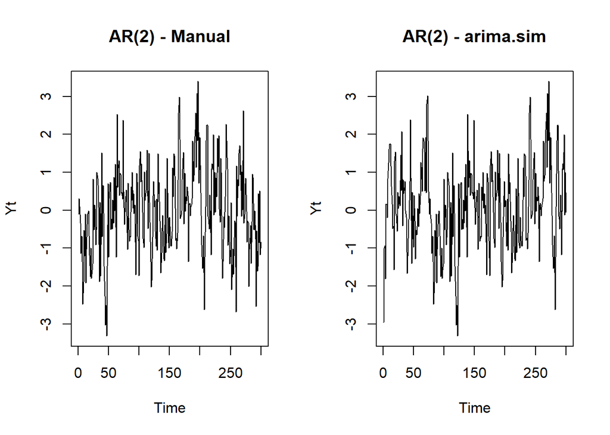

```r
par(mfrow = c(1, 2))
plot.ts(y_ar2_manual, main = "AR(2) - Manual", ylab = "Yt")
plot.ts(y_ar2_sim, main = "AR(2) - arima.sim", ylab = "Yt")
```

```r
par(mfrow = c(1, 1))
```

karena data overall sama saya y_ar2_sim

### ACF

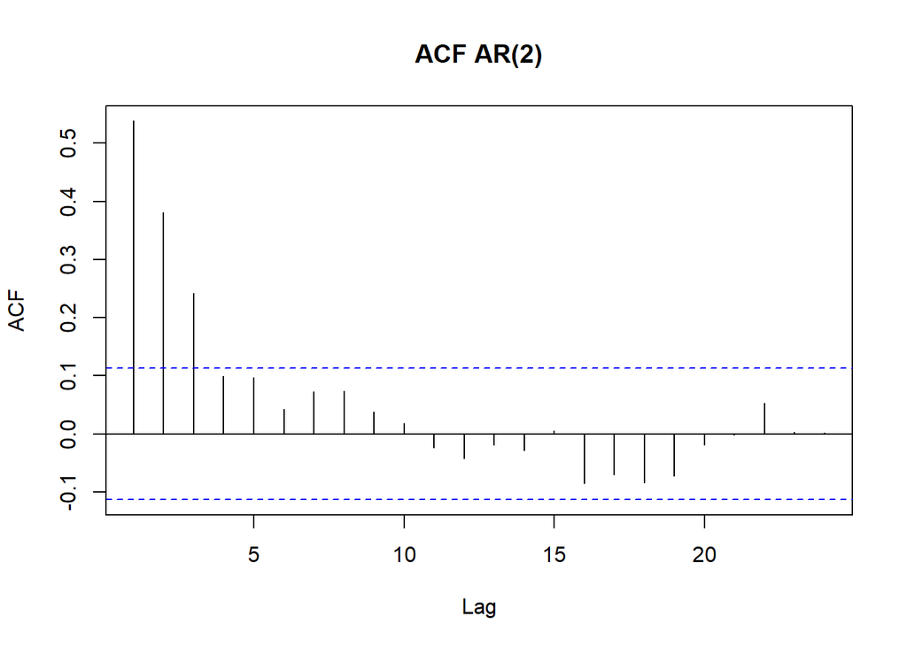

```r
acf(y_ar2_sim, main = "ACF AR(2)")
```

### PACF

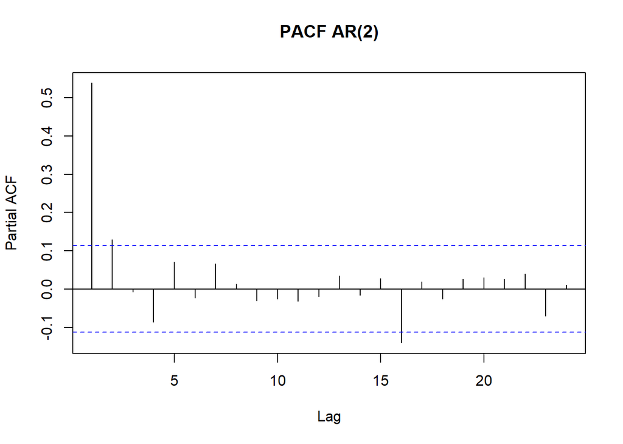

```r
pacf(y_ar2_sim, main = "PACF AR(2)")
```

### EACF

```r
eacf(y_ar2_sim)
```

```
## AR/MA
##   0 1 2 3 4 5 6 7 8 9 10 11 12 13
## 0 x x x o o o o o o o o  o  o  o
## 1 x o o x o o o o o o o  o  o  o
## 2 o o o o o o o o o o o  o  o  o
## 3 o x o o o o o o o o o  o  o  o
## 4 x x o o o x o o o o o  o  o  o
## 5 x x o x o o o o o o o  o  o  o
## 6 x x o x x o o o o o o  o  o  o
## 7 x x x x x o o o o o o  o  o  o
```

### Identifikasi Kestasioneran

Time series berosilasi di sekitar rata-rata tetap, ACF meluruh perlahan menuju nol dan PACF terputus setelah lag 2 — sesuai teori dan mengonfirmasi data **stasioner**.

## Scatterplot Yt terhadap lag

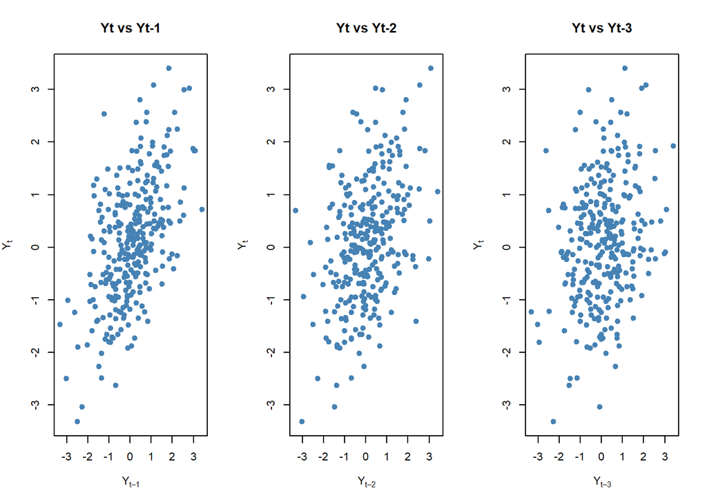

```r
par(mfrow = c(1, 3))
scatter_lag(y_ar2_sim, 1, "Yt vs Yt-1")
scatter_lag(y_ar2_sim, 2, "Yt vs Yt-2")
scatter_lag(y_ar2_sim, 3, "Yt vs Yt-3")
```

```r
par(mfrow = c(1, 1))
```

## Autokorelasi

### Empiris

```r
acf_empiris_ar <- acf(y_ar2_sim, plot = FALSE)$acf[2:4]
acf_empiris_ar
```

```
## [1] 0.38117471 0.24249327 0.09977753
```

### Teoritis

persamaan Yule-Walker:
$$\rho_1 =
\frac{\phi_1}{1-\phi_2}, \qquad \rho_k = \phi_1 \rho_{k-1} + \phi_2
\rho_{k-2}\ \ (k \ge 2), \qquad \rho_0 = 1$$

```r
phi1 <- 0.5
phi2 <- 0.2

rho <- numeric(3)
rho[1] <- phi1 / (1 - phi2)
rho[2] <- phi1 * rho[1] + phi2 * 1
rho[3] <- phi1 * rho[2] + phi2 * rho[1]

rho
```

```
## [1] 0.62500 0.51250 0.38125
```

# Proses ARMA(AutoRegressive Moving Average) (2,2)

ARMA(2,2):
$$Y_t = \phi_1 Y_{t-1} + \phi_2
Y_{t-2} + e_t + \theta_1 e_{t-1} + \theta_2 e_{t-2}$$

## Pembangkitan Data

### Dengan arima.sim

```r
set.seed(123)
y_arma22_sim <- arima.sim(model = list(ar = c(0.5, 0.2), ma = c(0.4, 0.6)), n = 300)
```

```r
y_arma22_sim
```

```
## Time Series:
## Start = 1
## End = 300
## Frequency = 1
##   [1] -3.111871501 -2.786997430 -1.125288998 -0.874935957 -0.034722620
##   [6]  0.840627099  1.472509888  2.614290237  3.145799875  3.418080389
##  [11]  2.911039673  2.140759158  1.112584421 -0.046028935 -0.514580254
##  [16] -2.031883364  0.419189325  1.119524563  1.305049942  0.749078814
##  [21] -0.666125042  0.168325317 -0.100438581  0.671395731  0.338369360
##  [26]  0.401165775  1.602582807  1.177472212  3.156576248  0.736155413
##  [31]  1.874387947  0.512873117  1.247565664  1.266686112  0.661953470
##  [36]  0.277960882 -1.181881273 -2.214494270 -2.079956469 -1.556330589
##  [41] -0.779751265  0.511253275  2.550470593  2.259849141  0.364488158
##  [46]  0.421666182 -1.408675956 -0.988250548 -0.451013000 -0.710506239
##  [51] -1.164739812 -1.202318563 -1.632907842 -0.997927905 -0.521294263
```

[output cut: 49 more lines]

### Manual

```r
generate_arma22_manual <- function(n, phi1, phi2, theta1, theta2) {
  burn <- 100
  total <- n + burn
  e <- rnorm(total)
  y <- numeric(total)
  y[1] <- e[1]
  y[2] <- e[2] + theta1 * e[1]
  for (t in 3:total) {
    y[t] <- phi1 * y[t - 1] + phi2 * y[t - 2] +
      e[t] + theta1 * e[t - 1] + theta2 * e[t - 2]
  }
  y[(burn + 1):total]
}

set.seed(123)
y_arma22_manual <- generate_arma22_manual(300, 0.5, 0.2, 0.4, 0.6)
```

```r
y_arma22_manual
```

```
##   [1]  1.206979549  0.569845888 -0.043863479 -0.200051687 -1.347449274
##   [6] -1.347935686 -2.317344397 -3.437179695 -3.700404704 -2.771497452
##  [11] -2.561713898 -0.905932937 -2.685214405 -1.861730245 -1.941455211
##  [16] -0.867494590 -0.284256476 -0.733370669 -1.466117663 -2.628167099
##  [21] -2.409134609 -3.245093974 -2.903333240 -3.121485353 -0.694318662
##  [26] -1.039516817  0.422301674 -0.215806989 -0.812883511 -0.858877383
##  [31]  0.246898250  0.938213193  1.607051305  0.856067059 -1.448062411
##  [36] -0.496277568 -2.777804785 -0.653664095  0.446305526 -0.143863283
##  [41]  1.287018676 -0.233082970 -1.115090303 -2.905005557 -4.826210570
##  [46] -5.074427980 -6.137496002 -4.298962971 -1.878758387 -1.833408624
##  [51]  0.240536032  0.065505786  1.193322883  0.195692367  0.013029057
##  [56] -0.887549341 -0.062009024 -0.523994524  0.891392537  0.133642607
##  [61]  1.734162966  0.040969069 -0.680882040  1.775224427  0.874901044
##  [66]  2.868603925  2.115028329  1.581018748  1.918806638  1.561048039
##  [71]  1.406607877  1.216033093  0.752159777  2.773287325  1.626679929
```

[output cut: 45 more lines]

## Plots dan Kestasioneran

ARMA hanya ditentukan oleh bagian AR-nya (komponen MA selalu stasioner). Karena $\phi_1,\phi_2$ sama dengan kasus AR(2) di atas dan sudah memenuhi syarat $\phi_1+\phi_2<1,\ \phi_2-\phi_1<1,\ -1<\phi_2<1$, maka proses ini **stasioner**.

### Time Series

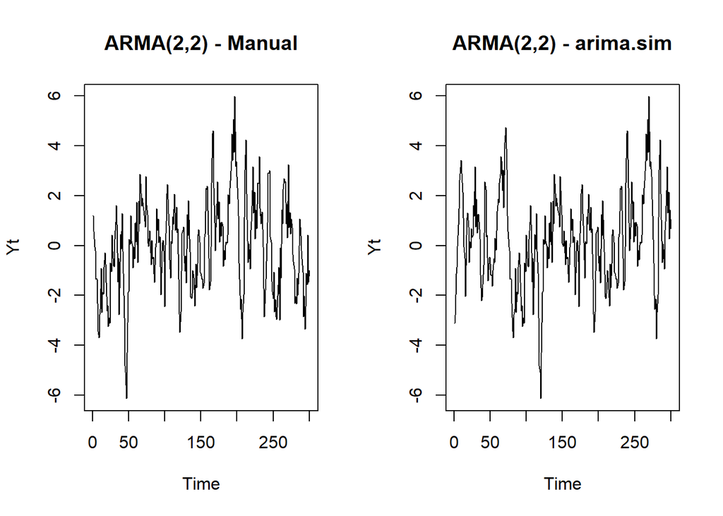

```r
par(mfrow = c(1, 2))
plot.ts(y_arma22_manual, main = "ARMA(2,2) - Manual", ylab = "Yt")
plot.ts(y_arma22_sim, main = "ARMA(2,2) - arima.sim", ylab = "Yt")
```

```r
par(mfrow = c(1, 1))
```

Karena kedua data hampir sama saya makai y_arma22_sim untuk selanjutnya

### ACF

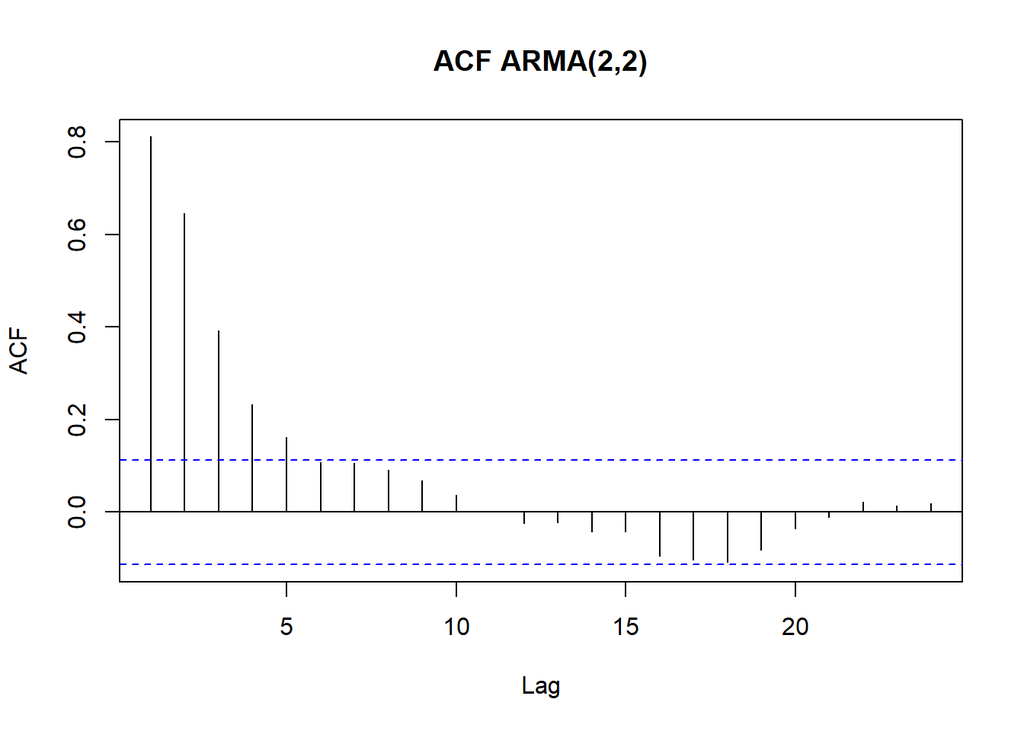

```r
acf(y_arma22_sim, main = "ACF ARMA(2,2)")
```

### PACF

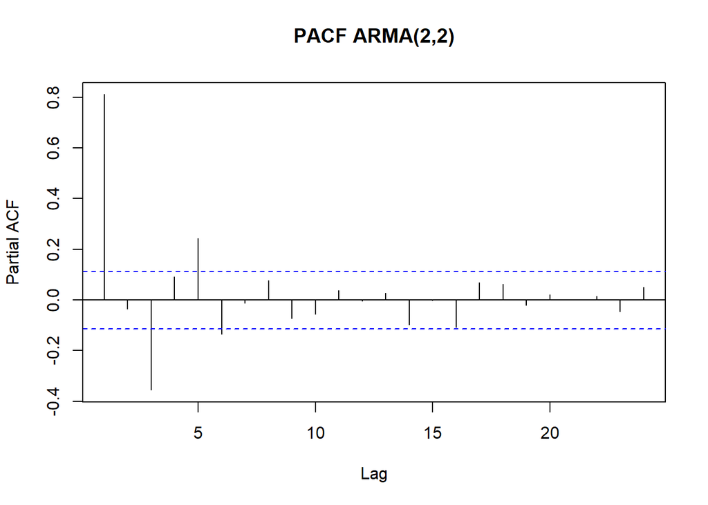

```r
pacf(y_arma22_sim, main = "PACF ARMA(2,2)")
```

### EACF

```r
eacf(y_arma22_sim)
```

```
## AR/MA
##   0 1 2 3 4 5 6 7 8 9 10 11 12 13
## 0 x x x x x o o o o o o  o  o  o
## 1 o x o o o x o o o o o  o  o  o
## 2 o x o o o x o o o o o  o  o  o
## 3 x x o x o x o o o o o  o  o  o
## 4 x x o x o x o o o o o  o  o  o
## 5 x x o x x o o o o o o  o  o  o
## 6 x x o x x o o o o o o  o  o  o
## 7 x x x x x o o o o o o  o  o  o
```

## Scatterplot terhadap lag

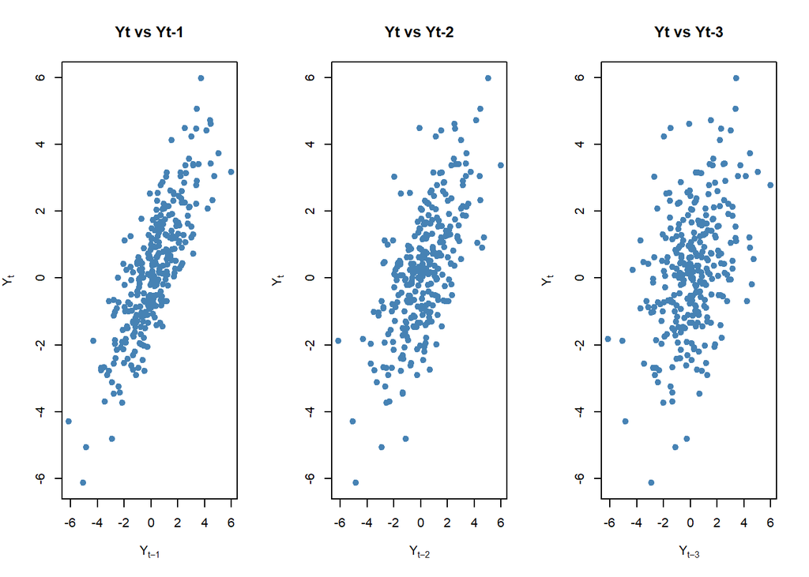

```r
par(mfrow = c(1, 3))
scatter_lag(y_arma22_sim, 1, "Yt vs Yt-1")
scatter_lag(y_arma22_sim, 2, "Yt vs Yt-2")
scatter_lag(y_arma22_sim, 3, "Yt vs Yt-3")
```

```r
par(mfrow = c(1, 1))
```

## Autokorelasi

### Empiris

```r
acf_empiris_arma <- acf(y_arma22_sim, plot = FALSE)$acf[2:4]
acf_empiris_arma
```

```
## [1] 0.6454029 0.3916683 0.2329892
```

### Teoritis

untuk lag $k>q=2$, ACF ARMA(2,2) mengikuti persamaan selisih yang sama seperti AR(2):

$$\rho_k = \phi_1 \rho_{k-1} + \phi_2
\rho_{k-2}, \qquad k>2$$

sedangkan $\rho_0,\rho_1,\rho_2$ dipengaruhi juga oleh komponen MA sehingga tidak memiliki bentuk tertutup sesederhana AR/MA murni — dalam praktik nilai-nilai ini dihitung memakai fungsi bawaan R, `ARMAacf()`, yang menghitungnya secara eksak melalui representasi $MA(\infty)$.

```r
acf_teori_arma <- ARMAacf(ar = c(0.5, 0.2), ma = c(0.4, 0.6), lag.max = 3)[2:4]
acf_teori_arma
```

```
##         1         2         3
## 0.8591993 0.7491908 0.5464353
```